# Optimal Treatment Analysis

## Outcome Variable

**Outcome Variable:** ever_wasted

## Predictor Variables

**Intervention Variable:** parity

**Adjustment Set:**

- arm
- W_mage
- meducyrs
- feducyrs
- W_mhtcm
- vagbrth
- single
- delta_W_mage
- delta_meducyrs
- delta_feducyrs
- delta_W_mhtcm
- delta_vagbrth
- delta_single

## Stratifying Variables

The analysis was stratified on these variable(s):

- agecat
- studyid
- country

## Data Summary

| agecat | studyid | country | parity | ever_wasted | n_cell | n |
| --- | --- | --- | --- | --- | --- | --- |
| 0-24 months | ki1000304b-SAS-CompFeed | INDIA | 1 | 0 | 96 | 463 |
| 0-24 months | ki1000304b-SAS-CompFeed | INDIA | 1 | 1 | 46 | 463 |
| 0-24 months | ki1000304b-SAS-CompFeed | INDIA | 2 | 0 | 68 | 463 |
| 0-24 months | ki1000304b-SAS-CompFeed | INDIA | 2 | 1 | 37 | 463 |
| 0-24 months | ki1000304b-SAS-CompFeed | INDIA | 3+ | 0 | 122 | 463 |
| 0-24 months | ki1000304b-SAS-CompFeed | INDIA | 3+ | 1 | 94 | 463 |
| 0-24 months | ki1000304b-SAS-FoodSuppl | INDIA | 1 | 0 | 11 | 101 |
| 0-24 months | ki1000304b-SAS-FoodSuppl | INDIA | 1 | 1 | 8 | 101 |
| 0-24 months | ki1000304b-SAS-FoodSuppl | INDIA | 2 | 0 | 10 | 101 |
| 0-24 months | ki1000304b-SAS-FoodSuppl | INDIA | 2 | 1 | 11 | 101 |
| 0-24 months | ki1000304b-SAS-FoodSuppl | INDIA | 3+ | 0 | 30 | 101 |
| 0-24 months | ki1000304b-SAS-FoodSuppl | INDIA | 3+ | 1 | 31 | 101 |
| 0-24 months | ki1017093b-PROVIDE | BANGLADESH | 1 | 0 | 163 | 700 |
| 0-24 months | ki1017093b-PROVIDE | BANGLADESH | 1 | 1 | 108 | 700 |
| 0-24 months | ki1017093b-PROVIDE | BANGLADESH | 2 | 0 | 170 | 700 |
| 0-24 months | ki1017093b-PROVIDE | BANGLADESH | 2 | 1 | 74 | 700 |
| 0-24 months | ki1017093b-PROVIDE | BANGLADESH | 3+ | 0 | 121 | 700 |
| 0-24 months | ki1017093b-PROVIDE | BANGLADESH | 3+ | 1 | 64 | 700 |
| 0-24 months | ki1066203-TanzaniaChild2 | TANZANIA, UNITED REPUBLIC OF | 1 | 0 | 624 | 2357 |
| 0-24 months | ki1066203-TanzaniaChild2 | TANZANIA, UNITED REPUBLIC OF | 1 | 1 | 197 | 2357 |
| 0-24 months | ki1066203-TanzaniaChild2 | TANZANIA, UNITED REPUBLIC OF | 2 | 0 | 583 | 2357 |
| 0-24 months | ki1066203-TanzaniaChild2 | TANZANIA, UNITED REPUBLIC OF | 2 | 1 | 188 | 2357 |
| 0-24 months | ki1066203-TanzaniaChild2 | TANZANIA, UNITED REPUBLIC OF | 3+ | 0 | 592 | 2357 |
| 0-24 months | ki1066203-TanzaniaChild2 | TANZANIA, UNITED REPUBLIC OF | 3+ | 1 | 173 | 2357 |
| 0-24 months | ki1101329-Keneba | GAMBIA | 1 | 0 | 160 | 1989 |
| 0-24 months | ki1101329-Keneba | GAMBIA | 1 | 1 | 80 | 1989 |
| 0-24 months | ki1101329-Keneba | GAMBIA | 2 | 0 | 138 | 1989 |
| 0-24 months | ki1101329-Keneba | GAMBIA | 2 | 1 | 76 | 1989 |
| 0-24 months | ki1101329-Keneba | GAMBIA | 3+ | 0 | 887 | 1989 |
| 0-24 months | ki1101329-Keneba | GAMBIA | 3+ | 1 | 648 | 1989 |

[output cut: 168 more lines]

The following strata were considered:

- agecat: 0-24 months, studyid: ki1000304b-SAS-CompFeed, country: INDIA
- agecat: 0-24 months, studyid: ki1000304b-SAS-FoodSuppl, country: INDIA
- agecat: 0-24 months, studyid: ki1017093b-PROVIDE, country: BANGLADESH
- agecat: 0-24 months, studyid: ki1066203-TanzaniaChild2, country: TANZANIA, UNITED REPUBLIC OF
- agecat: 0-24 months, studyid: ki1101329-Keneba, country: GAMBIA
- agecat: 0-24 months, studyid: ki1113344-GMS-Nepal, country: NEPAL
- agecat: 0-24 months, studyid: ki1126311-ZVITAMBO, country: ZIMBABWE
- agecat: 0-24 months, studyid: ki1135781-COHORTS, country: GUATEMALA
- agecat: 0-24 months, studyid: ki1135781-COHORTS, country: INDIA
- agecat: 0-24 months, studyid: ki1135781-COHORTS, country: PHILIPPINES
- agecat: 0-24 months, studyid: kiGH5241-JiVitA-3, country: BANGLADESH
- agecat: 0-6 months, studyid: ki1000304b-SAS-CompFeed, country: INDIA
- agecat: 0-6 months, studyid: ki1000304b-SAS-FoodSuppl, country: INDIA
- agecat: 0-6 months, studyid: ki1017093b-PROVIDE, country: BANGLADESH
- agecat: 0-6 months, studyid: ki1066203-TanzaniaChild2, country: TANZANIA, UNITED REPUBLIC OF
- agecat: 0-6 months, studyid: ki1101329-Keneba, country: GAMBIA
- agecat: 0-6 months, studyid: ki1113344-GMS-Nepal, country: NEPAL
- agecat: 0-6 months, studyid: ki1126311-ZVITAMBO, country: ZIMBABWE
- agecat: 0-6 months, studyid: ki1135781-COHORTS, country: GUATEMALA
- agecat: 0-6 months, studyid: ki1135781-COHORTS, country: INDIA
- agecat: 0-6 months, studyid: ki1135781-COHORTS, country: PHILIPPINES
- agecat: 0-6 months, studyid: kiGH5241-JiVitA-3, country: BANGLADESH
- agecat: 6-24 months, studyid: ki1000304b-SAS-CompFeed, country: INDIA
- agecat: 6-24 months, studyid: ki1000304b-SAS-FoodSuppl, country: INDIA
- agecat: 6-24 months, studyid: ki1017093b-PROVIDE, country: BANGLADESH
- agecat: 6-24 months, studyid: ki1066203-TanzaniaChild2, country: TANZANIA, UNITED REPUBLIC OF
- agecat: 6-24 months, studyid: ki1101329-Keneba, country: GAMBIA
- agecat: 6-24 months, studyid: ki1113344-GMS-Nepal, country: NEPAL
- agecat: 6-24 months, studyid: ki1126311-ZVITAMBO, country: ZIMBABWE
- agecat: 6-24 months, studyid: ki1135781-COHORTS, country: GUATEMALA
- agecat: 6-24 months, studyid: ki1135781-COHORTS, country: INDIA
- agecat: 6-24 months, studyid: ki1135781-COHORTS, country: PHILIPPINES
- agecat: 6-24 months, studyid: kiGH5241-JiVitA-3, country: BANGLADESH

### Dropped Strata

Some strata were dropped due to rare outcomes:

- agecat: 0-6 months, studyid: ki1000304b-SAS-FoodSuppl, country: INDIA

## Methods Detail

We’re interested in the causal parameters $E[Y_a]$ for all values of $a \in \mathcal{A}$. These parameters represent the mean outcome if, possibly contrary to fact, we intervened to set all units to have $A=a$. Under the randomization and positivity assumptions, these are identified by the statistical parameters $\psi_a=E_W[E_{Y|A,W}(Y|A=a,W)]$. In addition, we’re interested in the mean of $Y$, $E[Y]$ under no intervention (the observed mean). We will estimate these parameters by using SuperLearner to fit the relevant likelihood factors – $E_{Y|A,W}(Y|A=a,W)$ and $p(A=a|W)$, and then updating our likelihood fit using a joint TMLE.

For unadjusted analyses ($W=\{\}$), initial likelihoods were estimated using Lrnr_glm to estimate the simple $E(Y|A)$ and Lrnr_mean to estimate $p(A)$. For adjusted analyses, a small library containing Lrnr_glmnet, Lrnr_xgboost, and Lrnr_mean was used.

Having estimated these parameters, we will then use the delta method to estimate relative risks and attributable risks relative to a prespecified baseline level of $A$.

# Results Detail

## Results Plots

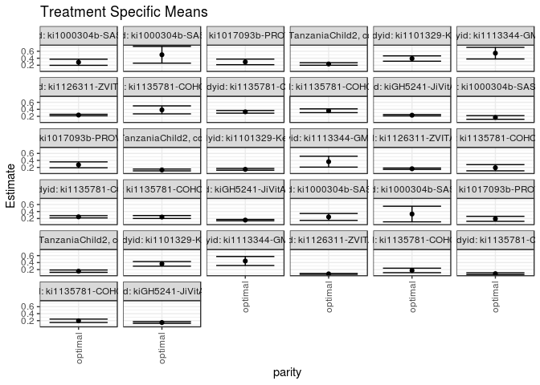

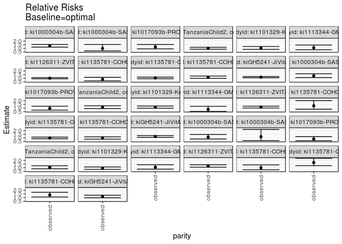

## Results Table

### Parameter: TSM

| agecat | studyid | country | intervention_level | baseline_level | estimate | ci_lower | ci_upper |
| --- | --- | --- | --- | --- | --- | --- | --- |
| 0-24 months | ki1000304b-SAS-CompFeed | INDIA | optimal | NA | 0.2852413 | 0.1977412 | 0.3727413 |
| 0-24 months | ki1000304b-SAS-FoodSuppl | INDIA | optimal | NA | 0.4991640 | 0.2585374 | 0.7397906 |
| 0-24 months | ki1017093b-PROVIDE | BANGLADESH | optimal | NA | 0.2947766 | 0.2150056 | 0.3745476 |
| 0-24 months | ki1066203-TanzaniaChild2 | TANZANIA, UNITED REPUBLIC OF | optimal | NA | 0.2353555 | 0.2003320 | 0.2703790 |
| 0-24 months | ki1101329-Keneba | GAMBIA | optimal | NA | 0.3910870 | 0.3148027 | 0.4673712 |
| 0-24 months | ki1113344-GMS-Nepal | NEPAL | optimal | NA | 0.5449640 | 0.3784892 | 0.7114388 |
| 0-24 months | ki1126311-ZVITAMBO | ZIMBABWE | optimal | NA | 0.2360403 | 0.2151184 | 0.2569622 |
| 0-24 months | ki1135781-COHORTS | GUATEMALA | optimal | NA | 0.3839904 | 0.2696289 | 0.4983519 |
| 0-24 months | ki1135781-COHORTS | INDIA | optimal | NA | 0.3284181 | 0.2902211 | 0.3666151 |
| 0-24 months | ki1135781-COHORTS | PHILIPPINES | optimal | NA | 0.3589621 | 0.3051014 | 0.4128228 |
| 0-24 months | kiGH5241-JiVitA-3 | BANGLADESH | optimal | NA | 0.2317183 | 0.2120440 | 0.2513926 |
| 0-6 months | ki1000304b-SAS-CompFeed | INDIA | optimal | NA | 0.1672320 | 0.1149089 | 0.2195551 |
| 0-6 months | ki1017093b-PROVIDE | BANGLADESH | optimal | NA | 0.2738034 | 0.1897493 | 0.3578574 |
| 0-6 months | ki1066203-TanzaniaChild2 | TANZANIA, UNITED REPUBLIC OF | optimal | NA | 0.1270195 | 0.1012287 | 0.1528102 |
| 0-6 months | ki1101329-Keneba | GAMBIA | optimal | NA | 0.1445166 | 0.1197841 | 0.1692492 |
| 0-6 months | ki1113344-GMS-Nepal | NEPAL | optimal | NA | 0.3639350 | 0.2077789 | 0.5200910 |
| 0-6 months | ki1126311-ZVITAMBO | ZIMBABWE | optimal | NA | 0.1615320 | 0.1419494 | 0.1811146 |
| 0-6 months | ki1135781-COHORTS | GUATEMALA | optimal | NA | 0.1906827 | 0.1018472 | 0.2795182 |
| 0-6 months | ki1135781-COHORTS | INDIA | optimal | NA | 0.2479702 | 0.2158142 | 0.2801263 |
| 0-6 months | ki1135781-COHORTS | PHILIPPINES | optimal | NA | 0.2423892 | 0.2005442 | 0.2842343 |
| 0-6 months | kiGH5241-JiVitA-3 | BANGLADESH | optimal | NA | 0.1542246 | 0.1356495 | 0.1727996 |
| 6-24 months | ki1000304b-SAS-CompFeed | INDIA | optimal | NA | 0.2443929 | 0.1460000 | 0.3427858 |
| 6-24 months | ki1000304b-SAS-FoodSuppl | INDIA | optimal | NA | 0.3274093 | 0.1046584 | 0.5501603 |
| 6-24 months | ki1017093b-PROVIDE | BANGLADESH | optimal | NA | 0.1910510 | 0.1201326 | 0.2619693 |
| 6-24 months | ki1066203-TanzaniaChild2 | TANZANIA, UNITED REPUBLIC OF | optimal | NA | 0.1543587 | 0.1212662 | 0.1874511 |
| 6-24 months | ki1101329-Keneba | GAMBIA | optimal | NA | 0.3633531 | 0.2979903 | 0.4287159 |
| 6-24 months | ki1113344-GMS-Nepal | NEPAL | optimal | NA | 0.4451097 | 0.3163014 | 0.5739180 |
| 6-24 months | ki1126311-ZVITAMBO | ZIMBABWE | optimal | NA | 0.0768957 | 0.0657281 | 0.0880633 |
| 6-24 months | ki1135781-COHORTS | GUATEMALA | optimal | NA | 0.1750585 | 0.1106884 | 0.2394287 |
| 6-24 months | ki1135781-COHORTS | INDIA | optimal | NA | 0.0829833 | 0.0578812 | 0.1080853 |
| 6-24 months | ki1135781-COHORTS | PHILIPPINES | optimal | NA | 0.1965365 | 0.1483054 | 0.2447675 |
| 6-24 months | kiGH5241-JiVitA-3 | BANGLADESH | optimal | NA | 0.1469778 | 0.1219286 | 0.1720269 |

### Parameter: E(Y)

| agecat | studyid | country | intervention_level | baseline_level | estimate | ci_lower | ci_upper |
| --- | --- | --- | --- | --- | --- | --- | --- |
| 0-24 months | ki1000304b-SAS-CompFeed | INDIA | observed | NA | 0.3822894 | 0.3008363 | 0.4637425 |
| 0-24 months | ki1000304b-SAS-FoodSuppl | INDIA | observed | NA | 0.4950495 | 0.3970561 | 0.5930429 |
| 0-24 months | ki1017093b-PROVIDE | BANGLADESH | observed | NA | 0.3514286 | 0.3160364 | 0.3868207 |
| 0-24 months | ki1066203-TanzaniaChild2 | TANZANIA, UNITED REPUBLIC OF | observed | NA | 0.2367416 | 0.2195770 | 0.2539062 |
| 0-24 months | ki1101329-Keneba | GAMBIA | observed | NA | 0.4042232 | 0.3826511 | 0.4257953 |
| 0-24 months | ki1113344-GMS-Nepal | NEPAL | observed | NA | 0.5913621 | 0.5520608 | 0.6306634 |
| 0-24 months | ki1126311-ZVITAMBO | ZIMBABWE | observed | NA | 0.2347539 | 0.2277172 | 0.2417906 |
| 0-24 months | ki1135781-COHORTS | GUATEMALA | observed | NA | 0.3216463 | 0.2858742 | 0.3574185 |
| 0-24 months | ki1135781-COHORTS | INDIA | observed | NA | 0.3378028 | 0.3241691 | 0.3514364 |
| 0-24 months | ki1135781-COHORTS | PHILIPPINES | observed | NA | 0.4036125 | 0.3861835 | 0.4210415 |
| 0-24 months | kiGH5241-JiVitA-3 | BANGLADESH | observed | NA | 0.2641779 | 0.2551015 | 0.2732542 |
| 0-6 months | ki1000304b-SAS-CompFeed | INDIA | observed | NA | 0.2207792 | 0.1636864 | 0.2778721 |
| 0-6 months | ki1017093b-PROVIDE | BANGLADESH | observed | NA | 0.2585714 | 0.2261125 | 0.2910304 |
| 0-6 months | ki1066203-TanzaniaChild2 | TANZANIA, UNITED REPUBLIC OF | observed | NA | 0.1395842 | 0.1255905 | 0.1535779 |
| 0-6 months | ki1101329-Keneba | GAMBIA | observed | NA | 0.1613611 | 0.1444653 | 0.1782570 |
| 0-6 months | ki1113344-GMS-Nepal | NEPAL | observed | NA | 0.2956811 | 0.2591967 | 0.3321655 |
| 0-6 months | ki1126311-ZVITAMBO | ZIMBABWE | observed | NA | 0.1810631 | 0.1746489 | 0.1874773 |
| 0-6 months | ki1135781-COHORTS | GUATEMALA | observed | NA | 0.2485323 | 0.2110255 | 0.2860391 |
| 0-6 months | ki1135781-COHORTS | INDIA | observed | NA | 0.2434743 | 0.2308547 | 0.2560940 |
| 0-6 months | ki1135781-COHORTS | PHILIPPINES | observed | NA | 0.2355453 | 0.2204685 | 0.2506222 |
| 0-6 months | kiGH5241-JiVitA-3 | BANGLADESH | observed | NA | 0.1822226 | 0.1742229 | 0.1902222 |
| 6-24 months | ki1000304b-SAS-CompFeed | INDIA | observed | NA | 0.2708333 | 0.2169112 | 0.3247555 |
| 6-24 months | ki1000304b-SAS-FoodSuppl | INDIA | observed | NA | 0.3800000 | 0.2843867 | 0.4756133 |
| 6-24 months | ki1017093b-PROVIDE | BANGLADESH | observed | NA | 0.1609756 | 0.1319065 | 0.1900447 |
| 6-24 months | ki1066203-TanzaniaChild2 | TANZANIA, UNITED REPUBLIC OF | observed | NA | 0.1600403 | 0.1439152 | 0.1761654 |
| 6-24 months | ki1101329-Keneba | GAMBIA | observed | NA | 0.3341996 | 0.3131165 | 0.3552826 |
| 6-24 months | ki1113344-GMS-Nepal | NEPAL | observed | NA | 0.4728814 | 0.4325613 | 0.5132014 |
| 6-24 months | ki1126311-ZVITAMBO | ZIMBABWE | observed | NA | 0.0939867 | 0.0884555 | 0.0995179 |
| 6-24 months | ki1135781-COHORTS | GUATEMALA | observed | NA | 0.1731092 | 0.1426836 | 0.2035348 |
| 6-24 months | ki1135781-COHORTS | INDIA | observed | NA | 0.1419682 | 0.1315821 | 0.1523542 |
| 6-24 months | ki1135781-COHORTS | PHILIPPINES | observed | NA | 0.2666429 | 0.2502871 | 0.2829988 |
| 6-24 months | kiGH5241-JiVitA-3 | BANGLADESH | observed | NA | 0.1648146 | 0.1556271 | 0.1740021 |

### Parameter: RR

| agecat | studyid | country | intervention_level | baseline_level | estimate | ci_lower | ci_upper |
| --- | --- | --- | --- | --- | --- | --- | --- |
| 0-24 months | ki1000304b-SAS-CompFeed | INDIA | observed | optimal | 1.3402319 | 1.1702550 | 1.534897 |
| 0-24 months | ki1000304b-SAS-FoodSuppl | INDIA | observed | optimal | 0.9917572 | 0.6431777 | 1.529254 |
| 0-24 months | ki1017093b-PROVIDE | BANGLADESH | observed | optimal | 1.1921861 | 0.9304495 | 1.527549 |
| 0-24 months | ki1066203-TanzaniaChild2 | TANZANIA, UNITED REPUBLIC OF | observed | optimal | 1.0058894 | 0.8846990 | 1.143681 |
| 0-24 months | ki1101329-Keneba | GAMBIA | observed | optimal | 1.0335891 | 0.8541040 | 1.250792 |
| 0-24 months | ki1113344-GMS-Nepal | NEPAL | observed | optimal | 1.0851399 | 0.8080596 | 1.457230 |
| 0-24 months | ki1126311-ZVITAMBO | ZIMBABWE | observed | optimal | 0.9945500 | 0.9145555 | 1.081542 |
| 0-24 months | ki1135781-COHORTS | GUATEMALA | observed | optimal | 0.8376416 | 0.6293106 | 1.114940 |
| 0-24 months | ki1135781-COHORTS | INDIA | observed | optimal | 1.0285753 | 0.9220222 | 1.147442 |
| 0-24 months | ki1135781-COHORTS | PHILIPPINES | observed | optimal | 1.1243874 | 0.9756474 | 1.295803 |
| 0-24 months | kiGH5241-JiVitA-3 | BANGLADESH | observed | optimal | 1.1400820 | 1.0596618 | 1.226606 |
| 0-6 months | ki1000304b-SAS-CompFeed | INDIA | observed | optimal | 1.3201972 | 1.0827248 | 1.609754 |
| 0-6 months | ki1017093b-PROVIDE | BANGLADESH | observed | optimal | 0.9443691 | 0.7138107 | 1.249397 |
| 0-6 months | ki1066203-TanzaniaChild2 | TANZANIA, UNITED REPUBLIC OF | observed | optimal | 1.0989200 | 0.9252114 | 1.305242 |
| 0-6 months | ki1101329-Keneba | GAMBIA | observed | optimal | 1.1165576 | 0.9779035 | 1.274871 |
| 0-6 months | ki1113344-GMS-Nepal | NEPAL | observed | optimal | 0.8124558 | 0.5357477 | 1.232081 |
| 0-6 months | ki1126311-ZVITAMBO | ZIMBABWE | observed | optimal | 1.1209116 | 0.9980389 | 1.258912 |
| 0-6 months | ki1135781-COHORTS | GUATEMALA | observed | optimal | 1.3033816 | 0.8430944 | 2.014962 |
| 0-6 months | ki1135781-COHORTS | INDIA | observed | optimal | 0.9818692 | 0.8726590 | 1.104747 |
| 0-6 months | ki1135781-COHORTS | PHILIPPINES | observed | optimal | 0.9717648 | 0.8277131 | 1.140887 |
| 0-6 months | kiGH5241-JiVitA-3 | BANGLADESH | observed | optimal | 1.1815405 | 1.0630823 | 1.313198 |
| 6-24 months | ki1000304b-SAS-CompFeed | INDIA | observed | optimal | 1.1081882 | 0.8393415 | 1.463148 |
| 6-24 months | ki1000304b-SAS-FoodSuppl | INDIA | observed | optimal | 1.1606266 | 0.6243546 | 2.157515 |
| 6-24 months | ki1017093b-PROVIDE | BANGLADESH | observed | optimal | 0.8425794 | 0.6042518 | 1.174908 |
| 6-24 months | ki1066203-TanzaniaChild2 | TANZANIA, UNITED REPUBLIC OF | observed | optimal | 1.0368079 | 0.8546921 | 1.257728 |
| 6-24 months | ki1101329-Keneba | GAMBIA | observed | optimal | 0.9197653 | 0.7682364 | 1.101182 |
| 6-24 months | ki1113344-GMS-Nepal | NEPAL | observed | optimal | 1.0623929 | 0.8049088 | 1.402244 |
| 6-24 months | ki1126311-ZVITAMBO | ZIMBABWE | observed | optimal | 1.2222629 | 1.0704246 | 1.395639 |
| 6-24 months | ki1135781-COHORTS | GUATEMALA | observed | optimal | 0.9888650 | 0.7095578 | 1.378118 |
| 6-24 months | ki1135781-COHORTS | INDIA | observed | optimal | 1.7108049 | 1.2762927 | 2.293246 |
| 6-24 months | ki1135781-COHORTS | PHILIPPINES | observed | optimal | 1.3567098 | 1.0709091 | 1.718784 |
| 6-24 months | kiGH5241-JiVitA-3 | BANGLADESH | observed | optimal | 1.1213572 | 0.9556130 | 1.315848 |

### Parameter: PAR

| agecat | studyid | country | intervention_level | baseline_level | estimate | ci_lower | ci_upper |
| --- | --- | --- | --- | --- | --- | --- | --- |
| 0-24 months | ki1000304b-SAS-CompFeed | INDIA | optimal | NA | 0.0970482 | 0.0641085 | 0.1299879 |
| 0-24 months | ki1000304b-SAS-FoodSuppl | INDIA | optimal | NA | -0.0041145 | -0.2203095 | 0.2120805 |
| 0-24 months | ki1017093b-PROVIDE | BANGLADESH | optimal | NA | 0.0566520 | -0.0164506 | 0.1297545 |
| 0-24 months | ki1066203-TanzaniaChild2 | TANZANIA, UNITED REPUBLIC OF | optimal | NA | 0.0013861 | -0.0288268 | 0.0315990 |
| 0-24 months | ki1101329-Keneba | GAMBIA | optimal | NA | 0.0131363 | -0.0615035 | 0.0877761 |
| 0-24 months | ki1113344-GMS-Nepal | NEPAL | optimal | NA | 0.0463982 | -0.1141467 | 0.2069430 |
| 0-24 months | ki1126311-ZVITAMBO | ZIMBABWE | optimal | NA | -0.0012864 | -0.0210784 | 0.0185056 |
| 0-24 months | ki1135781-COHORTS | GUATEMALA | optimal | NA | -0.0623441 | -0.1717766 | 0.0470885 |
| 0-24 months | ki1135781-COHORTS | INDIA | optimal | NA | 0.0093847 | -0.0265360 | 0.0453053 |
| 0-24 months | ki1135781-COHORTS | PHILIPPINES | optimal | NA | 0.0446504 | -0.0062390 | 0.0955397 |
| 0-24 months | kiGH5241-JiVitA-3 | BANGLADESH | optimal | NA | 0.0324596 | 0.0156233 | 0.0492958 |
| 0-6 months | ki1000304b-SAS-CompFeed | INDIA | optimal | NA | 0.0535472 | 0.0165902 | 0.0905043 |
| 0-6 months | ki1017093b-PROVIDE | BANGLADESH | optimal | NA | -0.0152319 | -0.0918969 | 0.0614331 |
| 0-6 months | ki1066203-TanzaniaChild2 | TANZANIA, UNITED REPUBLIC OF | optimal | NA | 0.0125648 | -0.0092692 | 0.0343987 |
| 0-6 months | ki1101329-Keneba | GAMBIA | optimal | NA | 0.0168445 | -0.0023515 | 0.0360405 |
| 0-6 months | ki1113344-GMS-Nepal | NEPAL | optimal | NA | -0.0682539 | -0.2196604 | 0.0831526 |
| 0-6 months | ki1126311-ZVITAMBO | ZIMBABWE | optimal | NA | 0.0195311 | 0.0007604 | 0.0383018 |
| 0-6 months | ki1135781-COHORTS | GUATEMALA | optimal | NA | 0.0578496 | -0.0253796 | 0.1410788 |
| 0-6 months | ki1135781-COHORTS | INDIA | optimal | NA | -0.0044959 | -0.0337401 | 0.0247483 |
| 0-6 months | ki1135781-COHORTS | PHILIPPINES | optimal | NA | -0.0068439 | -0.0457362 | 0.0320484 |
| 0-6 months | kiGH5241-JiVitA-3 | BANGLADESH | optimal | NA | 0.0279980 | 0.0118468 | 0.0441492 |
| 6-24 months | ki1000304b-SAS-CompFeed | INDIA | optimal | NA | 0.0264404 | -0.0394904 | 0.0923712 |
| 6-24 months | ki1000304b-SAS-FoodSuppl | INDIA | optimal | NA | 0.0525907 | -0.1501902 | 0.2553716 |
| 6-24 months | ki1017093b-PROVIDE | BANGLADESH | optimal | NA | -0.0300754 | -0.0935852 | 0.0334344 |
| 6-24 months | ki1066203-TanzaniaChild2 | TANZANIA, UNITED REPUBLIC OF | optimal | NA | 0.0056816 | -0.0241620 | 0.0355252 |
| 6-24 months | ki1101329-Keneba | GAMBIA | optimal | NA | -0.0291535 | -0.0942638 | 0.0359567 |
| 6-24 months | ki1113344-GMS-Nepal | NEPAL | optimal | NA | 0.0277717 | -0.0958193 | 0.1513626 |
| 6-24 months | ki1126311-ZVITAMBO | ZIMBABWE | optimal | NA | 0.0170911 | 0.0068436 | 0.0273385 |
| 6-24 months | ki1135781-COHORTS | GUATEMALA | optimal | NA | -0.0019493 | -0.0600378 | 0.0561392 |
| 6-24 months | ki1135781-COHORTS | INDIA | optimal | NA | 0.0589849 | 0.0343202 | 0.0836496 |
| 6-24 months | ki1135781-COHORTS | PHILIPPINES | optimal | NA | 0.0701065 | 0.0234907 | 0.1167222 |
| 6-24 months | kiGH5241-JiVitA-3 | BANGLADESH | optimal | NA | 0.0178368 | -0.0056722 | 0.0413459 |

### Parameter: PAF

| agecat | studyid | country | intervention_level | baseline_level | estimate | ci_lower | ci_upper |
| --- | --- | --- | --- | --- | --- | --- | --- |
| 0-24 months | ki1000304b-SAS-CompFeed | INDIA | optimal | NA | 0.2538604 | 0.1454854 | 0.3484907 |
| 0-24 months | ki1000304b-SAS-FoodSuppl | INDIA | optimal | NA | -0.0083113 | -0.5547803 | 0.3460865 |
| 0-24 months | ki1017093b-PROVIDE | BANGLADESH | optimal | NA | 0.1612048 | -0.0747494 | 0.3453567 |
| 0-24 months | ki1066203-TanzaniaChild2 | TANZANIA, UNITED REPUBLIC OF | optimal | NA | 0.0058549 | -0.1303280 | 0.1256303 |
| 0-24 months | ki1101329-Keneba | GAMBIA | optimal | NA | 0.0324976 | -0.1708176 | 0.2005066 |
| 0-24 months | ki1113344-GMS-Nepal | NEPAL | optimal | NA | 0.0784598 | -0.2375325 | 0.3137665 |
| 0-24 months | ki1126311-ZVITAMBO | ZIMBABWE | optimal | NA | -0.0054798 | -0.0934273 | 0.0753938 |
| 0-24 months | ki1135781-COHORTS | GUATEMALA | optimal | NA | -0.1938280 | -0.5890404 | 0.1030907 |
| 0-24 months | ki1135781-COHORTS | INDIA | optimal | NA | 0.0277815 | -0.0845726 | 0.1284965 |
| 0-24 months | ki1135781-COHORTS | PHILIPPINES | optimal | NA | 0.1106269 | -0.0249604 | 0.2282779 |
| 0-24 months | kiGH5241-JiVitA-3 | BANGLADESH | optimal | NA | 0.1228701 | 0.0563026 | 0.1847420 |
| 0-6 months | ki1000304b-SAS-CompFeed | INDIA | optimal | NA | 0.2425374 | 0.0764043 | 0.3787870 |
| 0-6 months | ki1017093b-PROVIDE | BANGLADESH | optimal | NA | -0.0589080 | -0.4009317 | 0.1996139 |
| 0-6 months | ki1066203-TanzaniaChild2 | TANZANIA, UNITED REPUBLIC OF | optimal | NA | 0.0900156 | -0.0808341 | 0.2338588 |
| 0-6 months | ki1101329-Keneba | GAMBIA | optimal | NA | 0.1043901 | -0.0225958 | 0.2156069 |
| 0-6 months | ki1113344-GMS-Nepal | NEPAL | optimal | NA | -0.2308362 | -0.8665503 | 0.1883648 |
| 0-6 months | ki1126311-ZVITAMBO | ZIMBABWE | optimal | NA | 0.1078690 | -0.0019649 | 0.2056631 |
| 0-6 months | ki1135781-COHORTS | GUATEMALA | optimal | NA | 0.2327650 | -0.1861068 | 0.5037128 |
| 0-6 months | ki1135781-COHORTS | INDIA | optimal | NA | -0.0184656 | -0.1459230 | 0.0948152 |
| 0-6 months | ki1135781-COHORTS | PHILIPPINES | optimal | NA | -0.0290556 | -0.2081480 | 0.1234887 |
| 0-6 months | kiGH5241-JiVitA-3 | BANGLADESH | optimal | NA | 0.1536473 | 0.0593390 | 0.2385005 |
| 6-24 months | ki1000304b-SAS-CompFeed | INDIA | optimal | NA | 0.0976262 | -0.1914101 | 0.3165422 |
| 6-24 months | ki1000304b-SAS-FoodSuppl | INDIA | optimal | NA | 0.1383965 | -0.6016540 | 0.5365037 |
| 6-24 months | ki1017093b-PROVIDE | BANGLADESH | optimal | NA | -0.1868318 | -0.6549393 | 0.1488693 |
| 6-24 months | ki1066203-TanzaniaChild2 | TANZANIA, UNITED REPUBLIC OF | optimal | NA | 0.0355011 | -0.1700120 | 0.2049158 |
| 6-24 months | ki1101329-Keneba | GAMBIA | optimal | NA | -0.0872339 | -0.3016826 | 0.0918850 |
| 6-24 months | ki1113344-GMS-Nepal | NEPAL | optimal | NA | 0.0587286 | -0.2423767 | 0.2868574 |
| 6-24 months | ki1126311-ZVITAMBO | ZIMBABWE | optimal | NA | 0.1818454 | 0.0657913 | 0.2834825 |
| 6-24 months | ki1135781-COHORTS | GUATEMALA | optimal | NA | -0.0112604 | -0.4093284 | 0.2743724 |
| 6-24 months | ki1135781-COHORTS | INDIA | optimal | NA | 0.4154798 | 0.2164807 | 0.5639369 |
| 6-24 months | ki1135781-COHORTS | PHILIPPINES | optimal | NA | 0.2629227 | 0.0662139 | 0.4181933 |
| 6-24 months | kiGH5241-JiVitA-3 | BANGLADESH | optimal | NA | 0.1082235 | -0.0464487 | 0.2400341 |